# single_component

Marina

2022-06-19

# Simple Examples: Single Components

## Overview

To do this, we simulated pure component CO2 and CH4 across a range of temperatures (30, 45, 60) *C and Pressures (5 bar to 200 bar). For each yco, T, P, we performed 3 replicates.

While assessing the accuracy of the model, we’ll also explore some properties and potential sources of variance that result from this method.

## Setup

### Starting Packages & Libraries

I also ran the gcmc simulation with the same species across the same range of temperatures and pressures, with 3 replicates per y, P, T. For each run, the following properties were used

s_box = 34 A N_steps = 1000 N_cycles = 1000

The results are located in the ./single_component_individual_runs/lower_p/ subdirectory of the project codebase.

## Data Presentation

### Simulation Pressure vs Reservor Overall

For a system comprised of only gas particles at a known T and P, that system’s derived thermodynamic properties should be the same as that of a reservoir gas of the same species with the same T and P. As such, one easy test for a system’s efficacy of modeling a simple system like a gas is to compare a derived pressure of the system with that of the reservoir used to determine the cell’s chemical potential. While not a particularly rigorous test for simulation accuracy, it does give an indication of significant biases for systems without an adsorbent.

For this set of analyses, I compared simulation pressure of completed runs to those of the reservoir. As such for each species I demonstrated this difference with a direct comparison, showing the difference or “error” of the simulation, and the percentage difference (percent error). “Completed Runs” simly have the results of the last 500 cycles averaged together to generate a result.

#### CO2, visual comparison

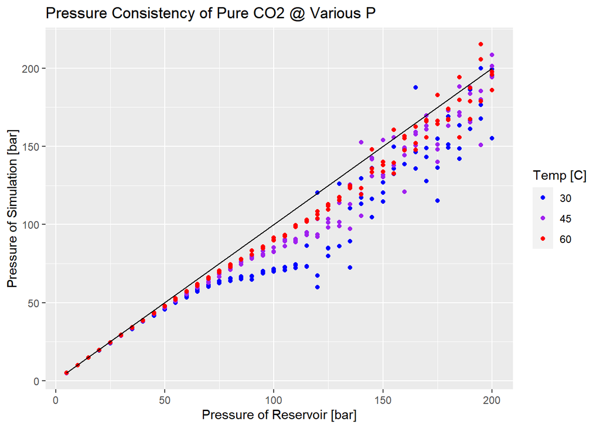

#### CO2, difference

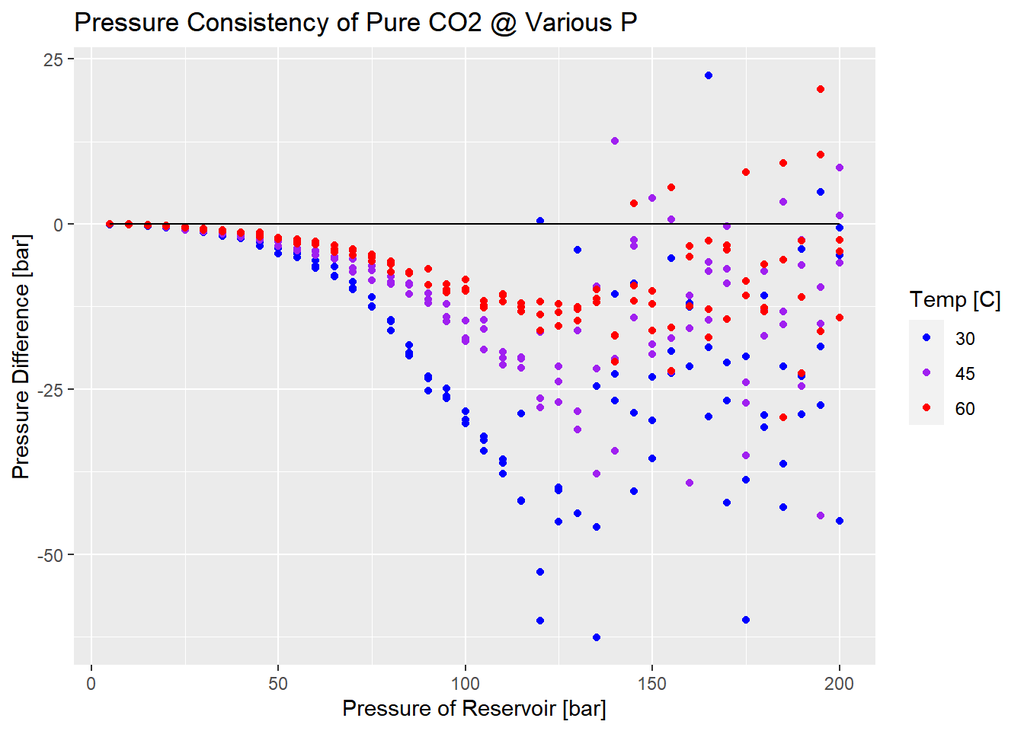

#### CO2, difference fraction

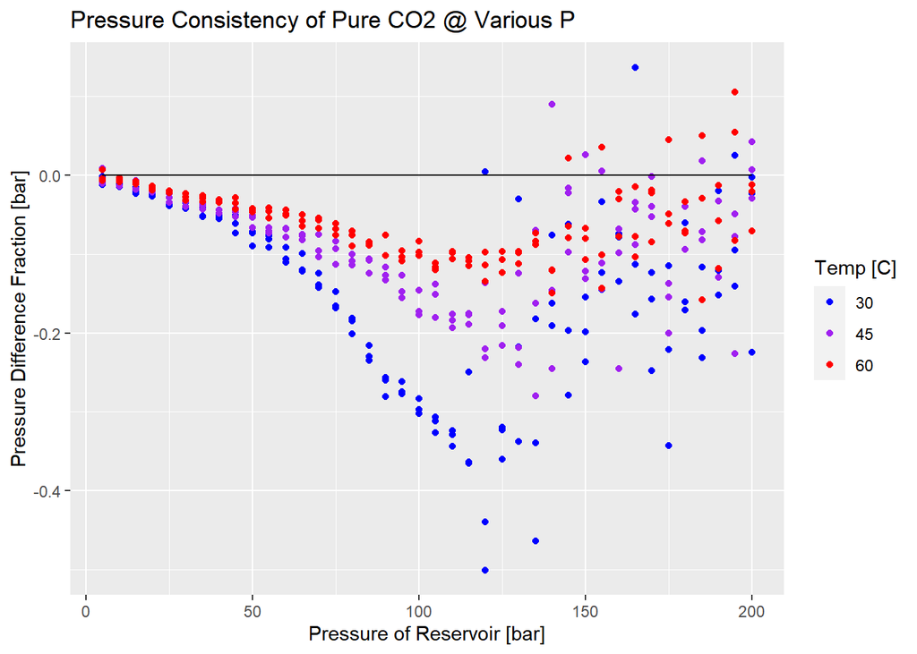

#### CH4, visual comparison

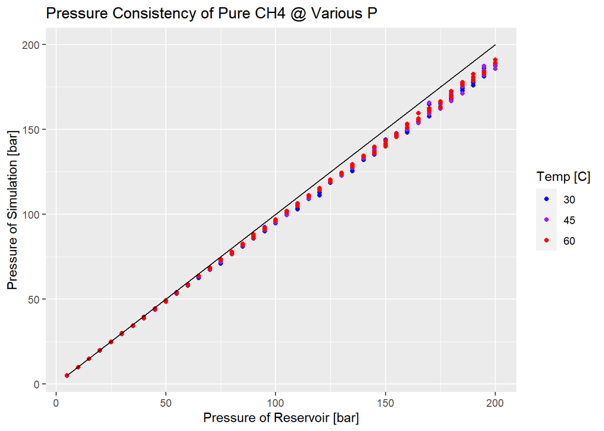

#### CH4, difference

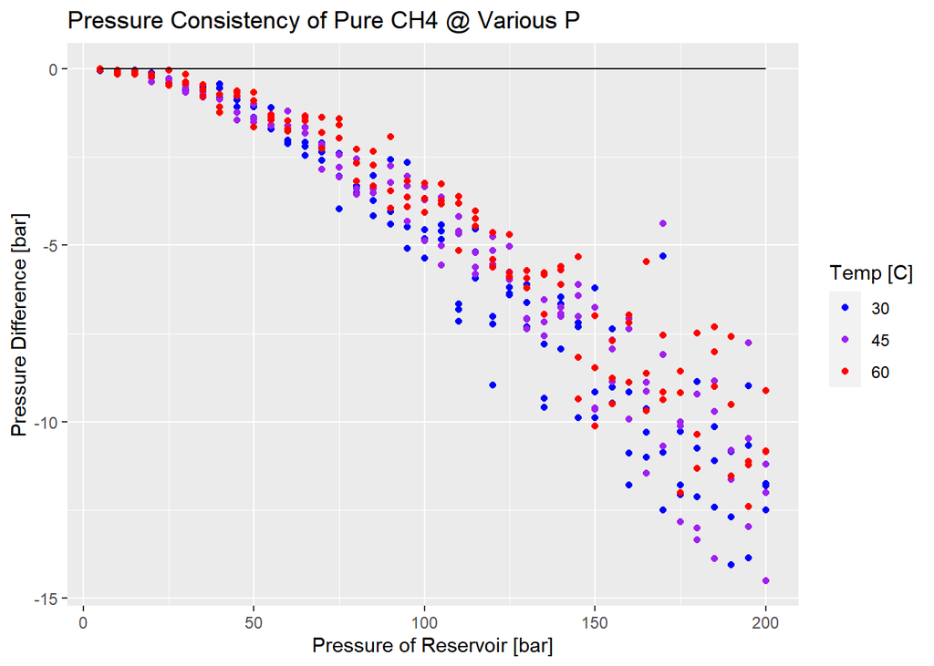

#### CH4, difference fraction

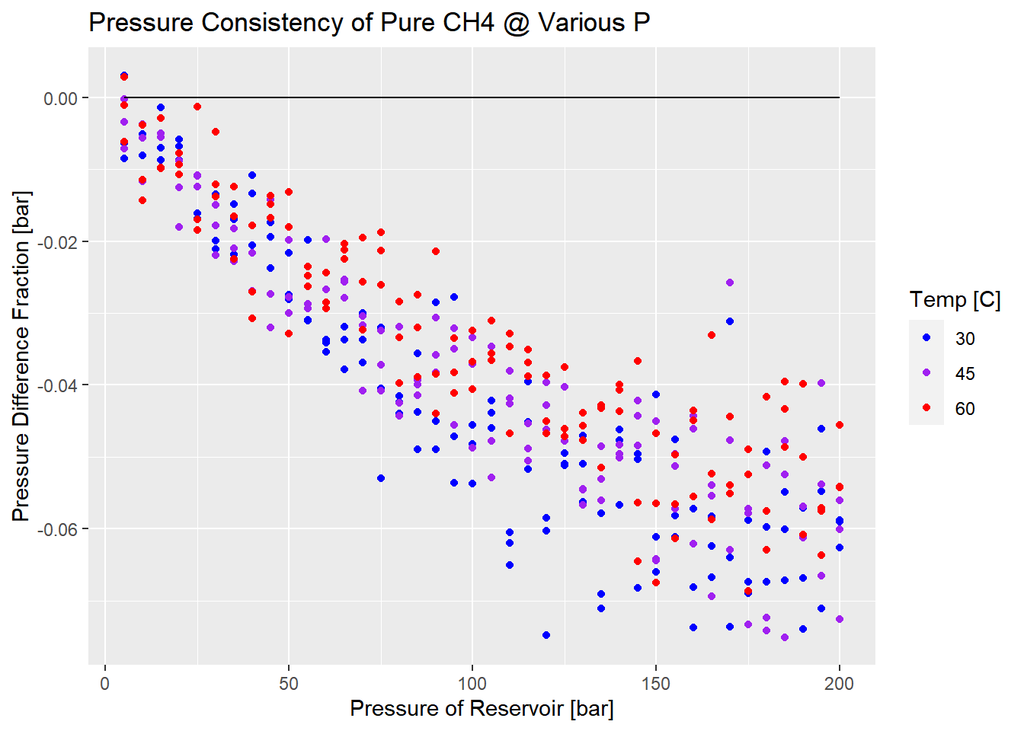

### Simulation Pressure vs Reservoir Zoomed In

Using the same measure of simulation performance of pressure difference, I’m now showing how that difference manifests over a simulation’s runtime. Since simulations like this need ample iterations to “complete” and hopefully converge, graphics like this can demonstrate how long a simulation should be run to receive an accurate (or at least precise) result. Naturally, the larger the unit cell, the more particles within the system, and the more complex the individual computational tasks are, the longer the simulation will take to converge in a time per iteration sense. In addition, the more non-ideal the gas is, the more iterations will be required to converge, such as Low Temperature, Higher Pressure, and higher Density. There are some techniques to deal with this and some have been described in the methods overview.

To generate these charts, a series of results were selected (10, 100, and 200 bar Reservoir) were taken and had their simulation pressure calculations shown over the course of a simulation.

#### CO2, 10 bar

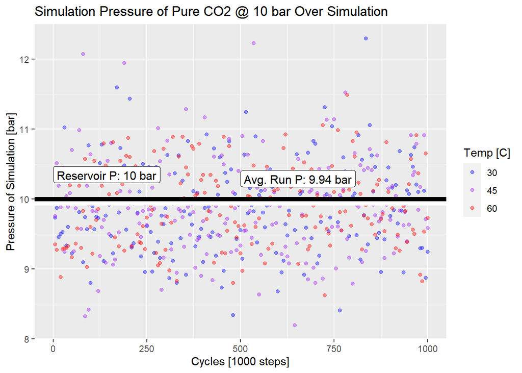

#### CO2, 100 bar

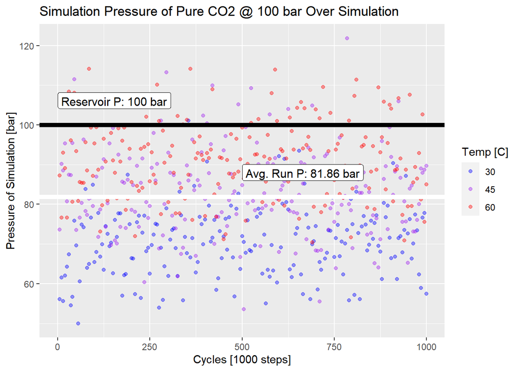

#### CO2, 200 bar

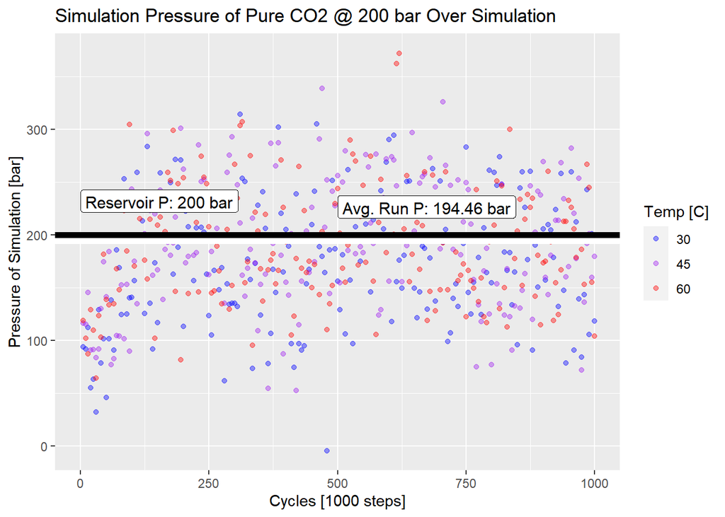

#### CH4, 10 bar

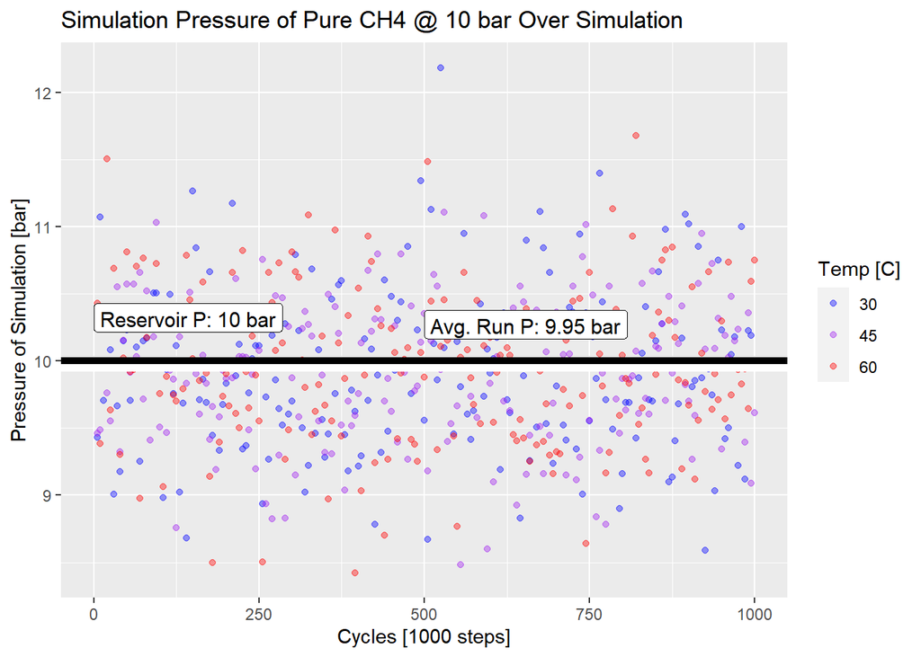

#### CH4, 100 bar

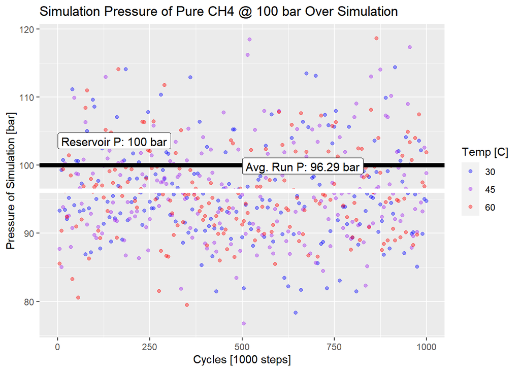

#### CH4, 200 bar

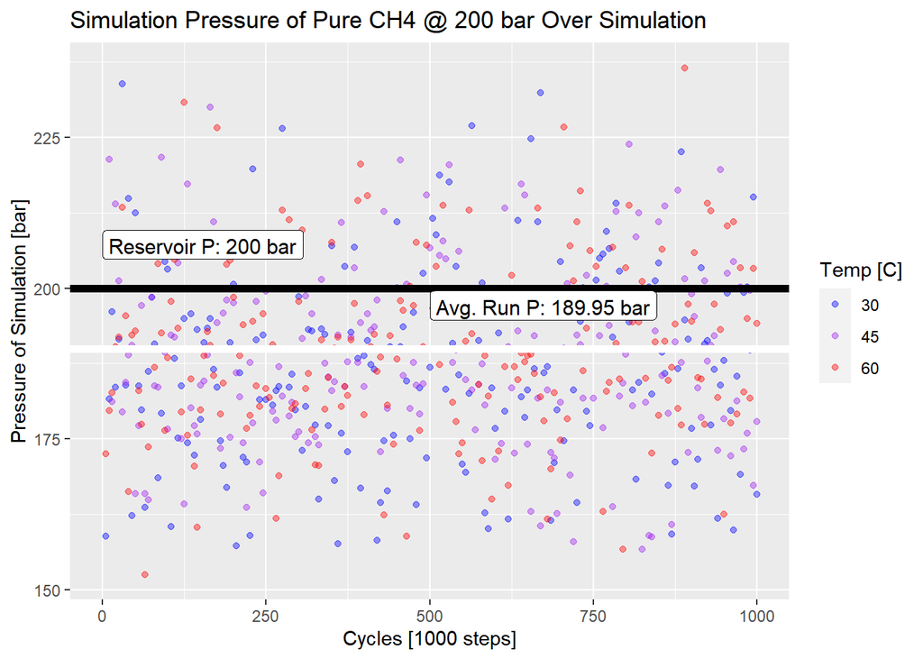

###

The same consistent shifts are noticeable on a more zoomed-in set of results. One additional characteristic of this presure difference is the bias is more extreme at lower temperatures. This could be due to the higher non-ideality which is failing to be captured by our choice in force field, or due to the system not equilibrating properly. While there doesn’t appear to be a significant trend in simulation pressure over the course of a run, there might be other ways to determine equilibration such as Internal Energy.

### Internal Energy

[This section could use some help, given that I still don’t know how to relate this “absolute” derivation of chemical potential with something shown in literature calculated from a reference state. Something about how T relates to potential energy within a gas probably]

As is the nature of any thermodynamic system, the trend is towards the lowest energy state possible provided no decrease in universal entropy. As such, it’s expected that this system will decrease in energy across iterations until it reaches some sort of minimum, either local or global. As such, it should be a decent metric for determining the “end” of a simulation if it asymptotes to some value. For these analyses, I used the default smoothing algorithm in the ggplot2’s package for readability.

#### CO2, 30C

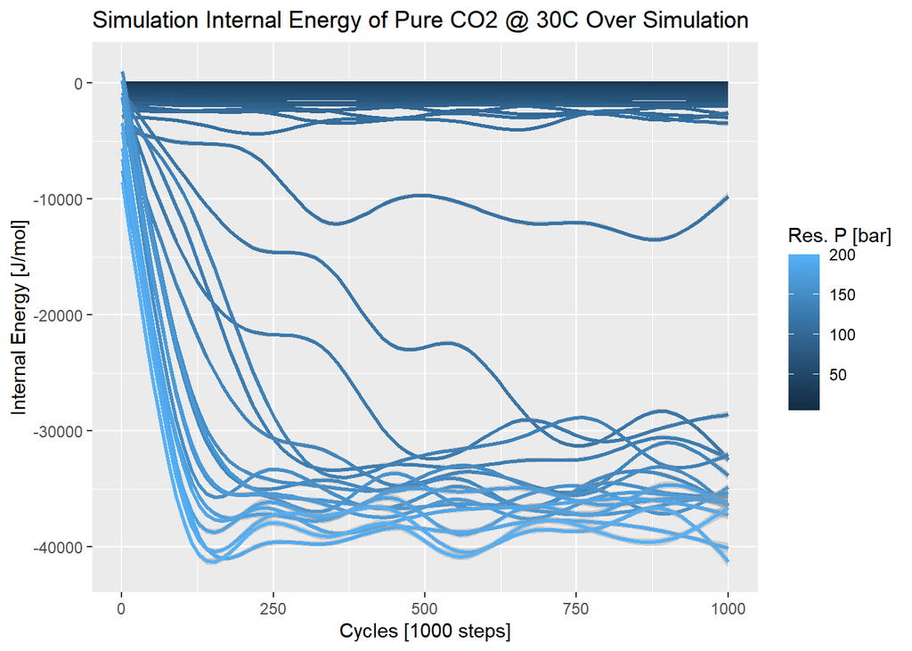

#### CO2, 45C

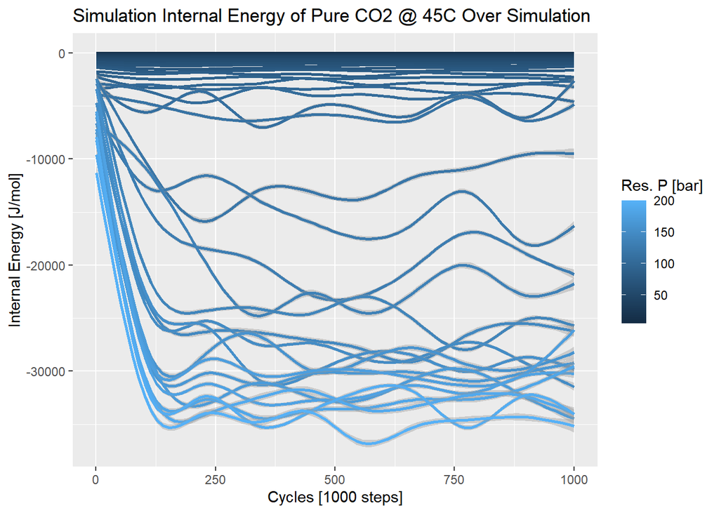

#### CO2, 60C

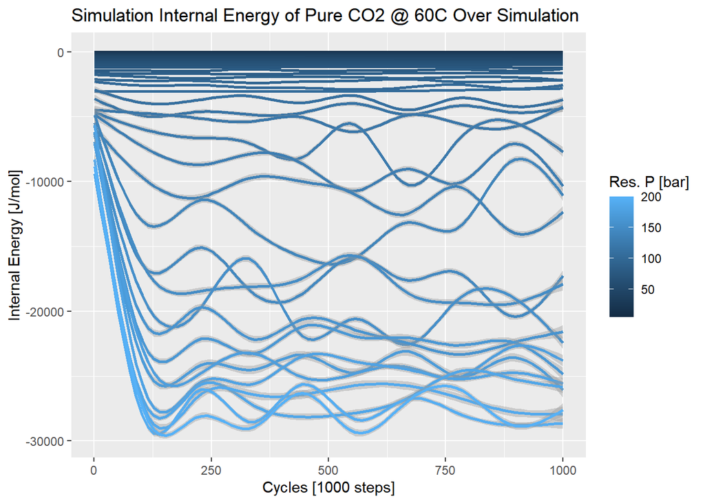

#### CH4, 30C

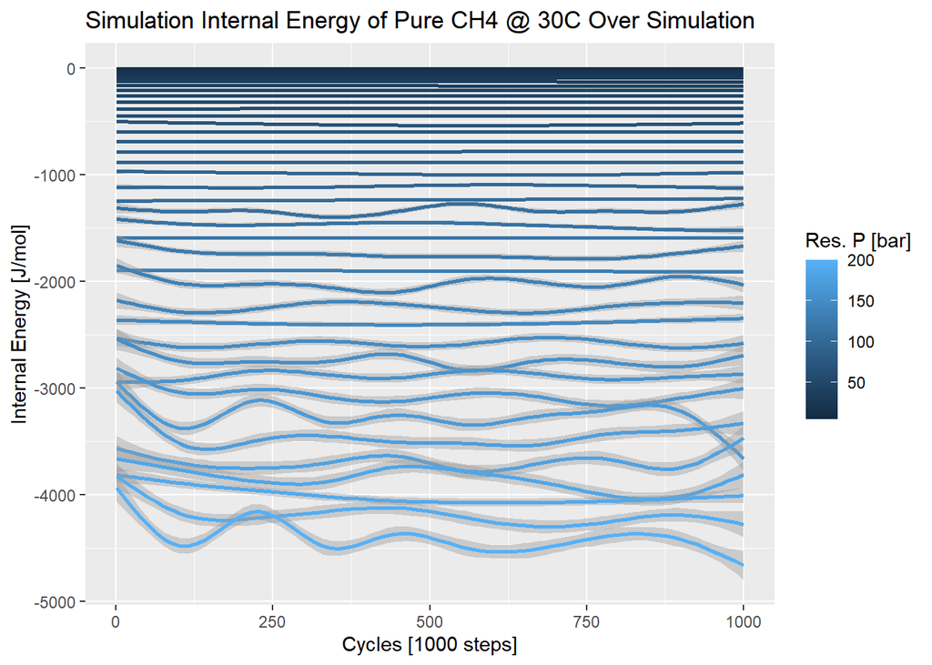

#### CH4, 45C

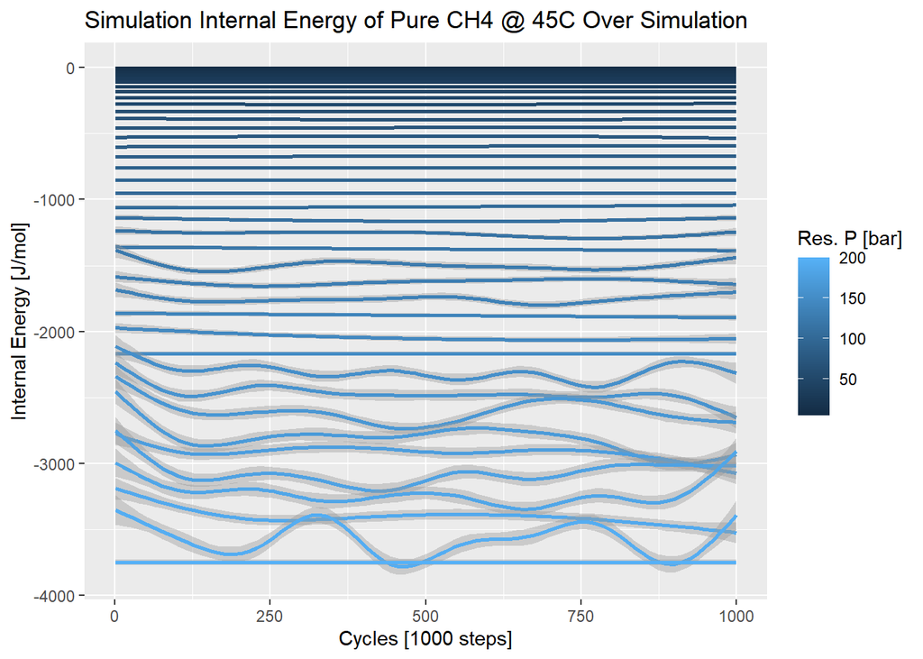

#### CH4, 60C

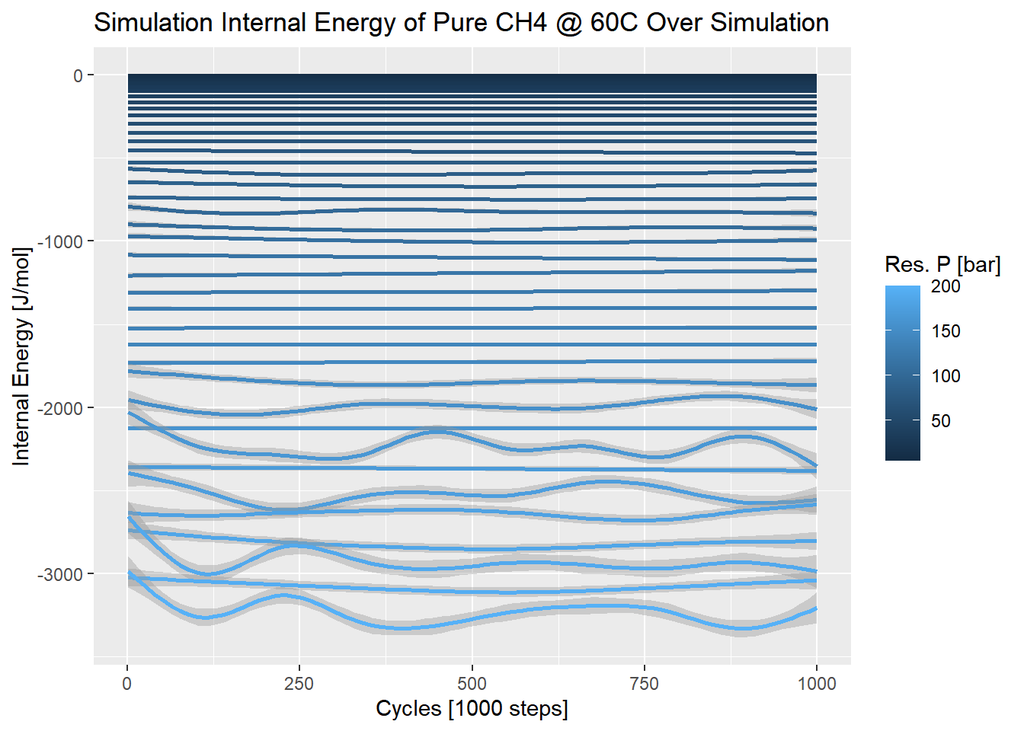

#### CO2, All Results

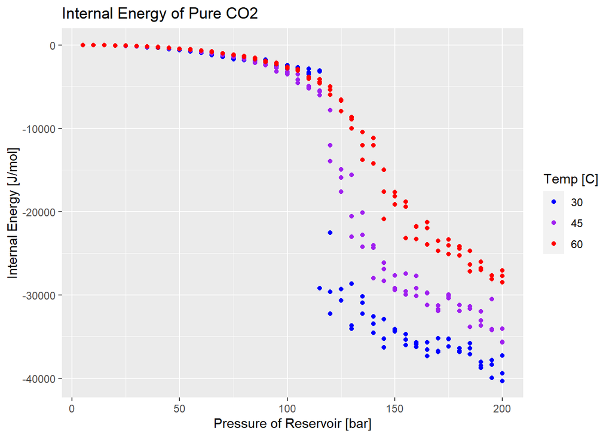

#### CH4, All Results

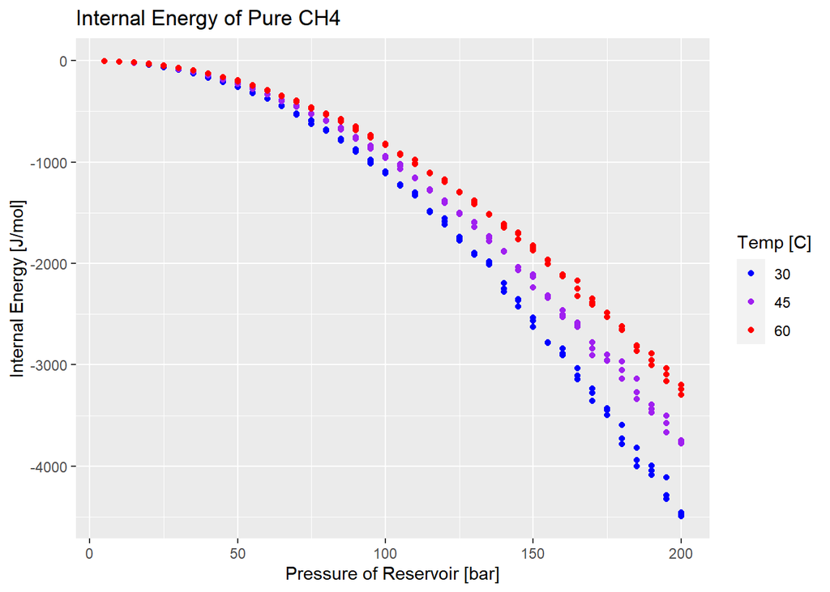

###

From these charts I think we can say anecdotally that these systems “equilibrated” after approximately 300 cycles, so for similar studies with these species I’ll be using at least that many iterations before collecting run data.

### Simulation Pressure

#### CO2, 30C

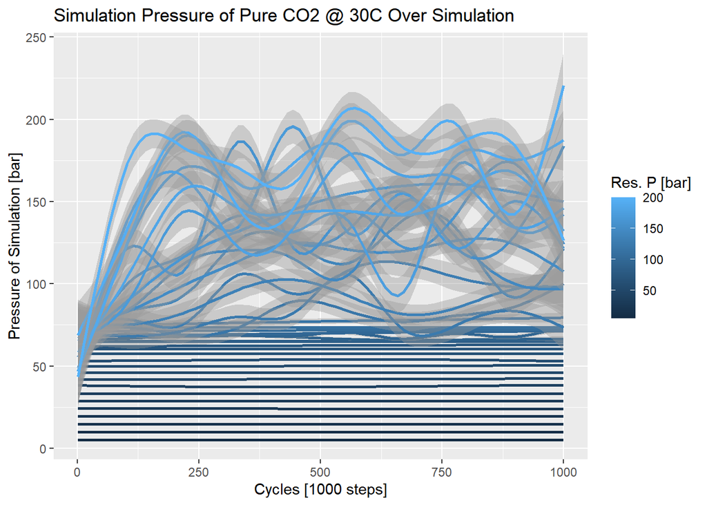

#### CO2, 45C

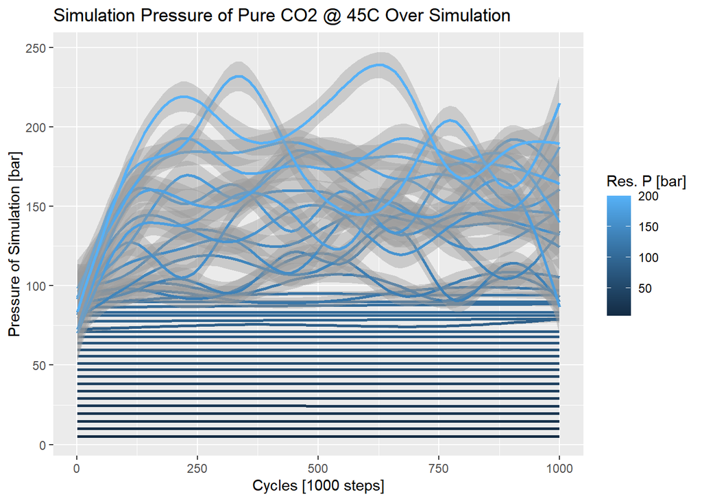

#### CO2, 60C

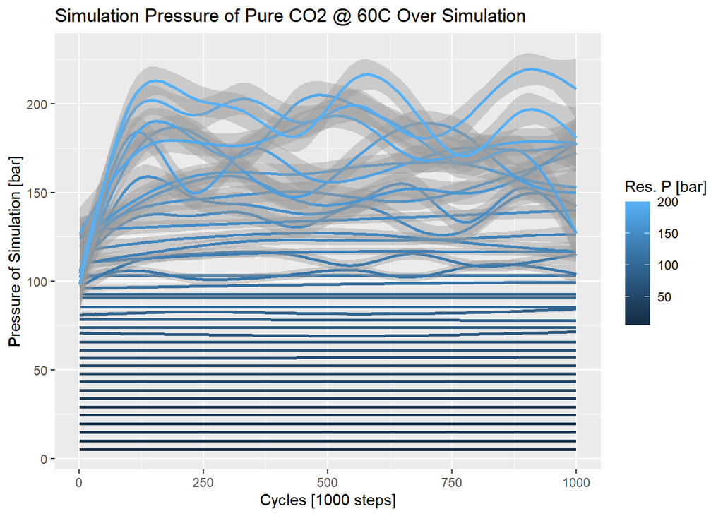

#### CH4, 30C

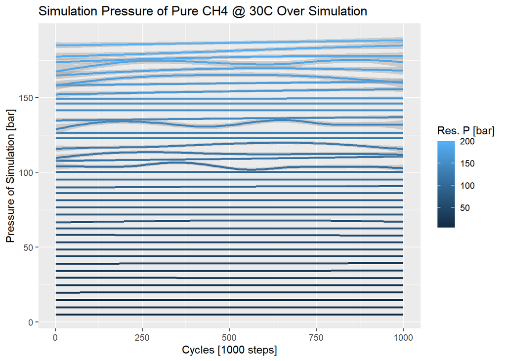

#### CH4, 45C

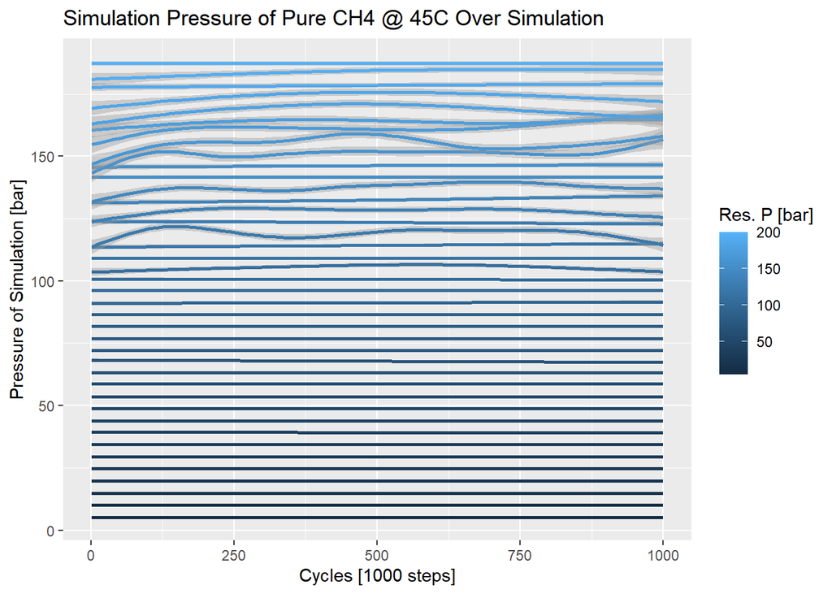

#### CH4, 60C

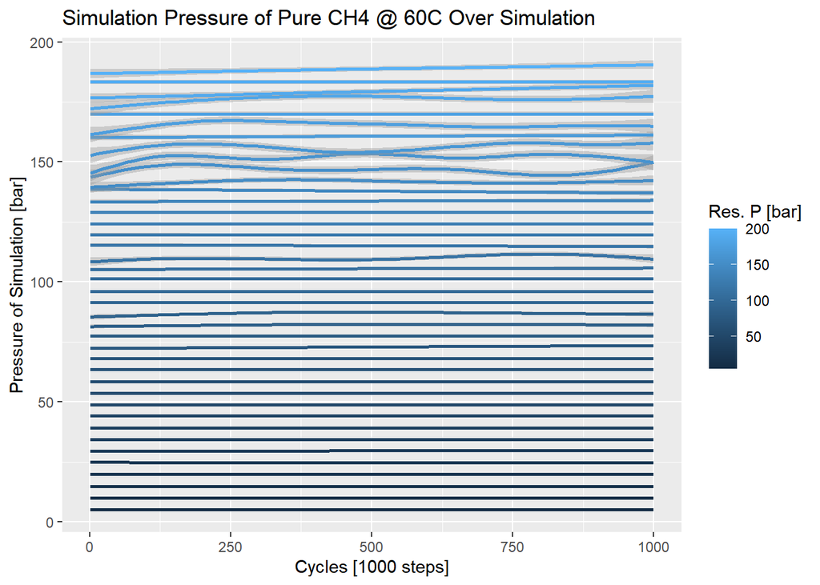

### Simulation Density

#### CO2, 30C

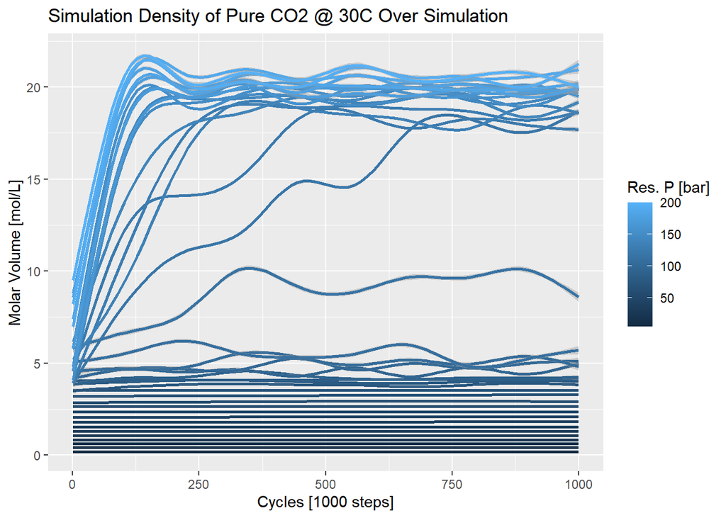

#### CO2, 45C

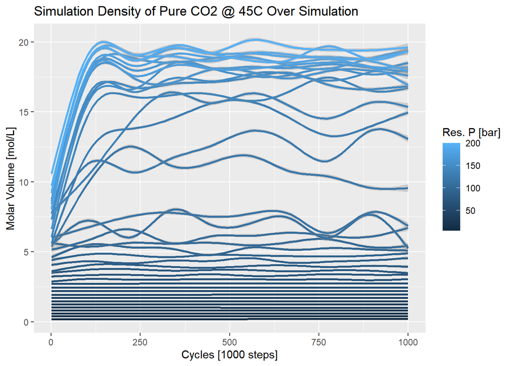

#### CO2, 60C

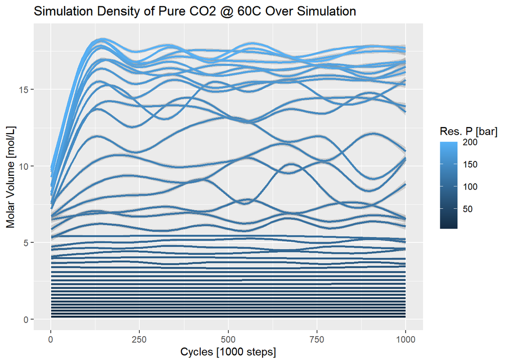

#### CH4, 30C

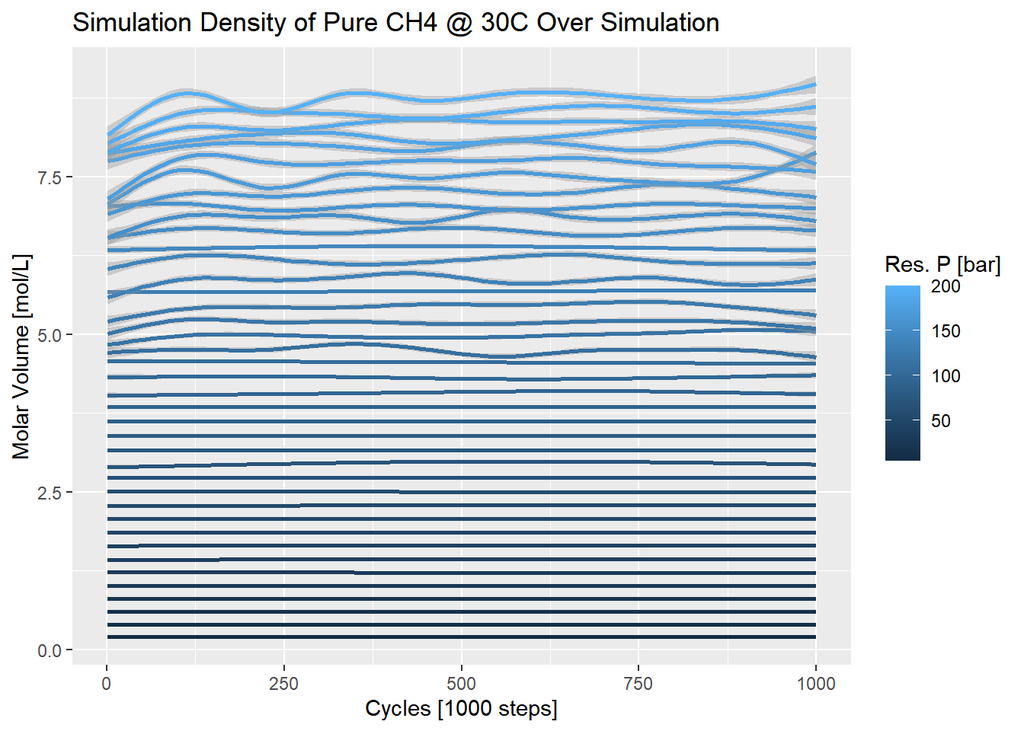

#### CH4, 45C

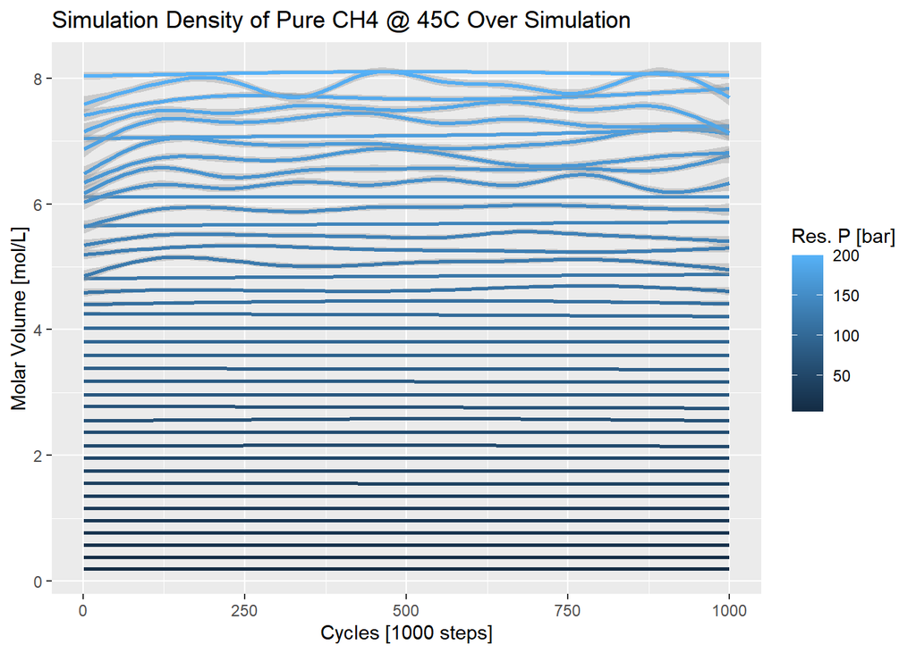

#### CH4, 60C

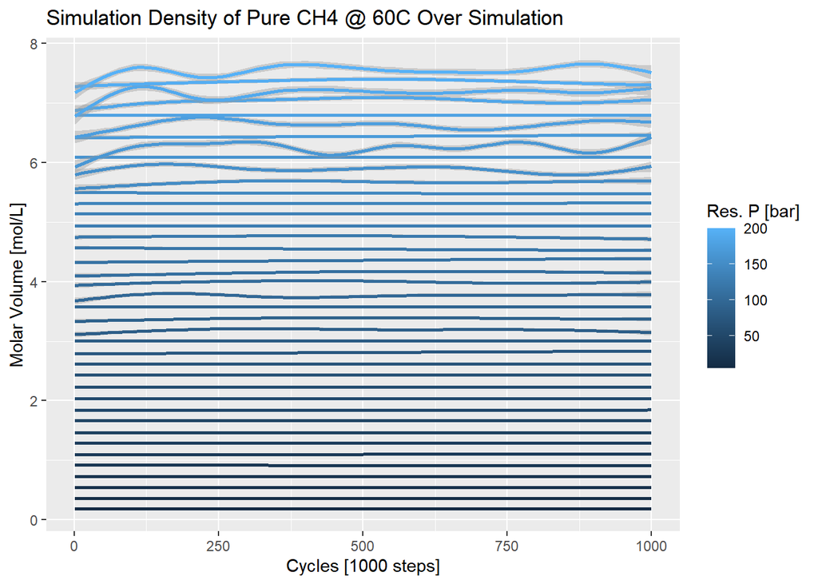